# Inferential - Session Models

June 2024

```r
update_mls_fwhm <- function(df) {
  df <- df %>%
    mutate(fwhm = case_when(
      fwhm == "fwhm-3.0" ~ "fwhm-3.6",
      fwhm == "fwhm-4.0" ~ "fwhm-4.8",
      fwhm == "fwhm-5.0" ~ "fwhm-6.0",
      fwhm == "fwhm-6.0" ~ "fwhm-7.2",
      fwhm == "fwhm-7.0" ~ "fwhm-8.4",
      TRUE ~ as.character(fwhm)  # if none of the conditions match, keep the original value
    ))
  return(df)
}

compare_models <- function(full_model, full_data, full_r2) {
  # List of analytic options
  analytic_options <- c("fwhm", "motion", "model", "con")
  model_fits <- list()

  # Summary matrix
  model_summary <- matrix(NA, ncol = 9, nrow = length(analytic_options))
  colnames(model_summary) <- c("Comparison", "Full AIC", "Full BIC", "New AIC", "New BIC", "χ2", "Orig R2", "New R2","∆R2")

  # Refit models with P - 1
  for (predictor in analytic_options) {
    # Update model, rerun, save fit
    updated_formula <- as.formula(paste(". ~ . -", predictor))
    model_rev <- update(full_model, updated_formula, REML = FALSE)
    model_fits[[predictor]] <- model_rev
  }

  # Compare models: [Full Model] v [P-1 Model] via anova
  mod_index = 0
  for (predictor in analytic_options) {
    mod_index = mod_index + 1
    # compare models + extract r2
    out <- anova(full_model, model_fits[[predictor]])
    marg_r2 <- round(as.numeric(r2_nakagawa(model_fits[[predictor]])[2]), 2)

    # Save values to summary table
    model_summary[mod_index, 1] <- paste("[Full] vs [New -", predictor, "]")
    model_summary[mod_index, 2] <- round(out[2, 2], 3)
    model_summary[mod_index, 3] <- round(out[2, 3], 3)
    model_summary[mod_index, 4] <- round(out[1, 2], 3)
    model_summary[mod_index, 5] <- round(out[1, 3], 3)
    model_summary[mod_index, 6] <- round(out[2, 6], 3)
    model_summary[mod_index, 7] <- full_r2
    model_summary[mod_index, 8] <- marg_r2
    model_summary[mod_index, 9] <- full_r2 - marg_r2
  }

  return(model_summary)
}

perform_emmeans_contrasts <- function(model) {
  # Get observation limit from the model
  mod_lmer_obs <- as.numeric(summary(model)$devcomp$dims[1])
  emm_options(lmerTest.limit = mod_lmer_obs)

  # list of contrasts and labels
  contrast_list <- list(
    pairwise ~ fwhm,
    pairwise ~ con,
    pairwise ~ motion,
    pairwise ~ model
  )

  labels <- c("FWHM", "Contrast", "Motion Corr", "Model Type")

  # contrasts and  summaries
  result_list <- list()
  for (i in seq_along(contrast_list)) {
    contrast <- contrast_list[[i]]
    mod_thsd <- emmeans(object = model, specs = contrast, pbkrtest.limit = mod_lmer_obs)

    # Store the table in the result list
    result_list[[i]] <- mod_thsd$contrasts %>% summary(infer = TRUE) %>%
      kable(digits = 4, caption = paste("Contrast Tukey HSD: ", labels[i])) %>%
      kable_styling()
  }

  # Return the list of tables
  return(result_list)
}
```

The packages are automatically loaded using `pacman`. The reported .html was last ran on the system: x86_64-apple-darwin17.0 and R version: R version 4.2.1 (2022-06-23)

In the Stage 1 [PCI Registered Report](https://doi.org/10.17605/OSF.IO/NQGEH) we are focused on Individual Continues (intraclass correlation) and the binary/continuoues group similarity (jaccard and spearman). Related to the descriptive file here, we describe each step that contained within this file that is relevant to the registered analyses

**continuous**

We stated:

Aim1: *HLM is used to regress the median ICC on the [four] analytic decisions as fixed effects with a random intercept and random slope for study across the suprathreshold task-positive and subthreshold maps. If the model does not converge, a random intercept only model will be fit (Matuschek et al., 2017). Multiple comparisons corrections are applied using the Tukey adjustment as implemented in the emmeans package (Lenth et al., 2023). For these HLM models, the interpretation focuses on the significant, non-zero effect of an independent variable (e.g., smoothing) on the dependent*

Aim2: *two HLMs are used to regress the Between Subject and Within Subject from the median ICC estimate on the [four] analytic decisions as fixed effects with a random intercept and random slope for study across the suprathreshold task-positive and subthreshold maps. If the model does not converge, a random intercept only model will be fit. Multiple comparisons corrections are applied using the Tukey adjustment. Like Aim 1, the interpretation focuses on the significant, non-zero effect of an independent variable (e.g., smoothing) on the dependent variable (e.g., median ICC) while the remaining independent variables are assumed to be zero.*

**group similarity**

We stated:

Aim1: *two HLMs are used to regress the Between Subject and Within Subject from the median ICC estimate on the [four] analytic decisions as fixed effects with a random intercept and random slope for study across the suprathreshold task-positive and subthreshold maps. If the model does not converge, a random intercept only model will be fit. Multiple comparisons corrections are applied using the Tukey adjustment. Like Aim 1, the interpretation focuses on the significant, non-zero effect of an independent variable (e.g., smoothing) on the dependent variable (e.g., median ICC) while the remaining independent variables are assumed to be zero.*

# 1 Load data

## 1.1 ABCD (PILOT N 20)

## 1.2 AHRB

## 1.3 MLS

## 1.4 combine data

# 2 Fitting HLM

Below using `lmer` to fit HLM model. The model has random intercept (sample). e.g., Level 1 model: Median ICC ~ Beta Estimates. Level 2 model: Random intercept. For reproducible reporting using tab_model

Using [emmeans](https://www.rdocumentation.org/packages/emmeans/versions/1.3.2/topics/emmeans-package) to control type I error rate of controls via [Tukey’s Honest Significant Test](https://en.wikipedia.org/wiki/Tukey%27s_range_test)

## 2.1 ICC

### 2.1.1 suprathreshold

#### 2.1.1.1 HLM Model

Running w/ random slope + intercept: `boundary (singular) fit: see help('isSingular')`, per registered report using random intercept only model.

R squared:

- Conditional: variance explained for ENTIRE model;
- Marginal: variance explained for Fixed effects only

```r
# if the above model does not converge, random intercept only model will be used:
model = lmer(median_est ~ fwhm + motion + model + con + (1 | study), data = icc_suprathresh, REML = FALSE)
orig_r2 = round(as.numeric(r2_nakagawa(model)[2]),2)
tab_model(model)
```

|  | median est |  |  |
| --- | --- | --- | --- |
| Predictors | Estimates | CI | p |
| (Intercept) | 0.22 | 0.18 – 0.26 | **<0.001** |
| fwhm [4.8] | 0.03 | 0.01 – 0.04 | **<0.001** |
| fwhm [6.0] | 0.05 | 0.03 – 0.06 | **<0.001** |
| fwhm [7.2] | 0.06 | 0.05 – 0.07 | **<0.001** |
| fwhm [8.4] | 0.07 | 0.06 – 0.09 | **<0.001** |
| motion [opt2] | 0.00 | -0.01 – 0.01 | 0.496 |
| motion [opt3] | -0.03 | -0.04 – -0.02 | **<0.001** |
| motion [opt4] | -0.03 | -0.04 – -0.02 | **<0.001** |
| model [CueMod] | 0.07 | 0.06 – 0.08 | **<0.001** |
| model [FixMod] | 0.03 | 0.02 – 0.04 | **<0.001** |
| con [LgainNeut] | -0.11 | -0.12 – -0.10 | **<0.001** |
| con [SgainBase] | -0.02 | -0.03 – -0.01 | **0.001** |
| con [SgainNeut] | -0.19 | -0.20 – -0.18 | **<0.001** |
| Random Effects |  |  |  |
| σ<sup>2</sup> | 0.00 |  |  |
| τ<sub>00</sub> <sub>study</sub> | 0.00 |  |  |
| ICC | 0.27 |  |  |
| N <sub>study</sub> | 3 |  |  |
| Observations | 720 |  |  |
| Marginal R<sup>2</sup> / Conditional R<sup>2</sup> | 0.661 / 0.752 |  |  |

```r
options(scipen = 999, digits = 4)
model_summary <- compare_models(full_model = model, full_data = icc_suprathresh, full_r2 = orig_r2)

kable(model_summary, caption = "Model outputs for Supra-threshold ICC", booktabs = TRUE) %>%
  kable_styling(font_size = 12, position = 'center',html_font = "Times New Roman")
```

Model outputs for Supra-threshold ICC

| Comparison | Full AIC | Full BIC | New AIC | New BIC | χ2 | Orig R2 | New R2 | ∆R2 |
| --- | --- | --- | --- | --- | --- | --- | --- | --- |
| [Full] vs [New - fwhm ] | -2137.573 | -2068.884 | -1986.242 | -1935.87 | 159.331 | 0.66 | 0.6 | 0.0600000000000001 |
| [Full] vs [New - motion ] | -2137.573 | -2068.884 | -2078.688 | -2023.737 | 64.885 | 0.66 | 0.64 | 0.02 |
| [Full] vs [New - model ] | -2137.573 | -2068.884 | -1967.334 | -1907.804 | 174.239 | 0.66 | 0.59 | 0.0700000000000001 |
| [Full] vs [New - con ] | -2137.573 | -2068.884 | -1343.36 | -1288.409 | 800.213 | 0.66 | 0.15 | 0.51 |

#### 2.1.1.2 Tukey’s emmeans

```r
perform_emmeans_contrasts(model)
```

[[1]]

Contrast Tukey HSD: FWHM

| contrast | estimate | SE | df | lower.CL | upper.CL | t.ratio | p.value |
| --- | --- | --- | --- | --- | --- | --- | --- |
| fwhm3.6 - fwhm4.8 | -0.0258 | 0.0063 | 729.2 | -0.0431 | -0.0085 | -4.084 | 0.0005 |
| fwhm3.6 - fwhm6.0 | -0.0466 | 0.0063 | 729.2 | -0.0639 | -0.0293 | -7.375 | 0.0000 |
| fwhm3.6 - fwhm7.2 | -0.0625 | 0.0063 | 729.2 | -0.0798 | -0.0452 | -9.886 | 0.0000 |
| fwhm3.6 - fwhm8.4 | -0.0743 | 0.0063 | 729.2 | -0.0915 | -0.0570 | -11.741 | 0.0000 |
| fwhm4.8 - fwhm6.0 | -0.0208 | 0.0063 | 729.2 | -0.0381 | -0.0035 | -3.291 | 0.0092 |
| fwhm4.8 - fwhm7.2 | -0.0367 | 0.0063 | 729.2 | -0.0540 | -0.0194 | -5.801 | 0.0000 |
| fwhm4.8 - fwhm8.4 | -0.0484 | 0.0063 | 729.2 | -0.0657 | -0.0311 | -7.657 | 0.0000 |
| fwhm6.0 - fwhm7.2 | -0.0159 | 0.0063 | 729.2 | -0.0332 | 0.0014 | -2.510 | 0.0894 |
| fwhm6.0 - fwhm8.4 | -0.0276 | 0.0063 | 729.2 | -0.0449 | -0.0103 | -4.366 | 0.0001 |
| fwhm7.2 - fwhm8.4 | -0.0117 | 0.0063 | 729.2 | -0.0290 | 0.0056 | -1.856 | 0.3424 |

[[2]]

Contrast Tukey HSD: Contrast

| contrast | estimate | SE | df | lower.CL | upper.CL | t.ratio | p.value |
| --- | --- | --- | --- | --- | --- | --- | --- |
| LgainBase - LgainNeut | 0.1119 | 0.0057 | 729.2 | 0.0974 | 0.1265 | 19.789 | 0.0000 |
| LgainBase - SgainBase | 0.0190 | 0.0057 | 729.2 | 0.0044 | 0.0335 | 3.352 | 0.0047 |
| LgainBase - SgainNeut | 0.1896 | 0.0057 | 729.2 | 0.1750 | 0.2041 | 33.515 | 0.0000 |
| LgainNeut - SgainBase | -0.0930 | 0.0057 | 729.2 | -0.1075 | -0.0784 | -16.436 | 0.0000 |
| LgainNeut - SgainNeut | 0.0776 | 0.0057 | 729.2 | 0.0631 | 0.0922 | 13.726 | 0.0000 |
| SgainBase - SgainNeut | 0.1706 | 0.0057 | 729.2 | 0.1560 | 0.1852 | 30.163 | 0.0000 |

[[3]]

Contrast Tukey HSD: Motion Corr

| contrast | estimate | SE | df | lower.CL | upper.CL | t.ratio | p.value |
| --- | --- | --- | --- | --- | --- | --- | --- |
| opt1 - opt2 | -0.0038 | 0.0057 | 729.2 | -0.0184 | 0.0107 | -0.6758 | 0.9063 |
| opt1 - opt3 | 0.0288 | 0.0057 | 729.2 | 0.0142 | 0.0433 | 5.0869 | 0.0000 |
| opt1 - opt4 | 0.0324 | 0.0057 | 729.2 | 0.0178 | 0.0469 | 5.7194 | 0.0000 |
| opt2 - opt3 | 0.0326 | 0.0057 | 729.2 | 0.0180 | 0.0472 | 5.7626 | 0.0000 |
| opt2 - opt4 | 0.0362 | 0.0057 | 729.2 | 0.0216 | 0.0507 | 6.3952 | 0.0000 |
| opt3 - opt4 | 0.0036 | 0.0057 | 729.2 | -0.0110 | 0.0181 | 0.6325 | 0.9215 |

[[4]]

Contrast Tukey HSD: Model Type

| contrast | estimate | SE | df | lower.CL | upper.CL | t.ratio | p.value |
| --- | --- | --- | --- | --- | --- | --- | --- |
| AntMod - CueMod | -0.0682 | 0.0049 | 729.2 | -0.0797 | -0.0567 | -13.921 | 0 |
| AntMod - FixMod | -0.0325 | 0.0049 | 729.2 | -0.0441 | -0.0210 | -6.645 | 0 |
| CueMod - FixMod | 0.0356 | 0.0049 | 729.2 | 0.0241 | 0.0471 | 7.276 | 0 |

### 2.1.2 Interaction: Con * Model

#### 2.1.2.1 HLM Model

```r
model_interact = lmer(median_est ~ fwhm + motion + model * con + (1 | study), data = icc_subthresh, REML = FALSE)
tab_model(model_interact)
```

|  | median est |  |  |
| --- | --- | --- | --- |
| Predictors | Estimates | CI | p |
| (Intercept) | 0.10 | 0.07 – 0.13 | **<0.001** |
| fwhm [4.8] | 0.02 | 0.01 – 0.03 | **<0.001** |
| fwhm [6.0] | 0.04 | 0.03 – 0.05 | **<0.001** |
| fwhm [7.2] | 0.05 | 0.05 – 0.06 | **<0.001** |
| fwhm [8.4] | 0.07 | 0.06 – 0.07 | **<0.001** |
| motion [opt2] | 0.00 | -0.01 – 0.01 | 0.835 |
| motion [opt3] | -0.03 | -0.03 – -0.02 | **<0.001** |
| motion [opt4] | -0.03 | -0.03 – -0.02 | **<0.001** |
| model [CueMod] | 0.11 | 0.10 – 0.12 | **<0.001** |
| model [FixMod] | 0.06 | 0.05 – 0.07 | **<0.001** |
| con [LgainNeut] | -0.01 | -0.02 – 0.00 | 0.086 |
| con [SgainBase] | -0.01 | -0.02 – 0.00 | 0.271 |
| con [SgainNeut] | -0.05 | -0.06 – -0.04 | **<0.001** |
| model [CueMod] × con [LgainNeut] | -0.12 | -0.13 – -0.10 | **<0.001** |
| model [FixMod] × con [LgainNeut] | -0.07 | -0.08 – -0.05 | **<0.001** |
| model [CueMod] × con [SgainBase] | 0.01 | -0.00 – 0.03 | 0.141 |
| model [FixMod] × con [SgainBase] | -0.02 | -0.03 – -0.00 | **0.050** |
| model [CueMod] × con [SgainNeut] | -0.11 | -0.12 – -0.09 | **<0.001** |
| model [FixMod] × con [SgainNeut] | -0.07 | -0.09 – -0.05 | **<0.001** |
| Random Effects |  |  |  |
| σ<sup>2</sup> | 0.00 |  |  |
| τ<sub>00</sub> <sub>study</sub> | 0.00 |  |  |
| ICC | 0.34 |  |  |
| N <sub>study</sub> | 3 |  |  |
| Observations | 720 |  |  |
| Marginal R<sup>2</sup> / Conditional R<sup>2</sup> | 0.729 / 0.822 |  |  |

#### 2.1.2.2 Tukey’s emmeans

```r
emmeans(model_interact, ~  "model", by = "con", adjust = "sidak")
```

```
## con = LgainBase:
##  model  emmean     SE   df lower.CL upper.CL
##  AntMod 0.1236 0.0162 5.32  0.06803    0.179
##  CueMod 0.2308 0.0162 5.32  0.17518    0.286
##  FixMod 0.1837 0.0162 5.32  0.12808    0.239
##
## con = LgainNeut:
##  model  emmean     SE   df lower.CL upper.CL
##  AntMod 0.1140 0.0162 5.32  0.05835    0.170
##  CueMod 0.1061 0.0162 5.32  0.05050    0.162
##  FixMod 0.1069 0.0162 5.32  0.05125    0.162
##
## con = SgainBase:
##  model  emmean     SE   df lower.CL upper.CL
##  AntMod 0.1174 0.0162 5.32  0.06183    0.173
##  CueMod 0.2364 0.0162 5.32  0.18073    0.292
##  FixMod 0.1618 0.0162 5.32  0.10623    0.217
##
## con = SgainNeut:
##  model  emmean     SE   df lower.CL upper.CL
##  AntMod 0.0728 0.0162 5.32  0.01718    0.128
##  CueMod 0.0738 0.0162 5.32  0.01823    0.129
##  FixMod 0.0635 0.0162 5.32  0.00786    0.119
##
## Results are averaged over the levels of: fwhm, motion
## Degrees-of-freedom method: kenward-roger
## Confidence level used: 0.95
## Conf-level adjustment: sidak method for 3 estimates
```

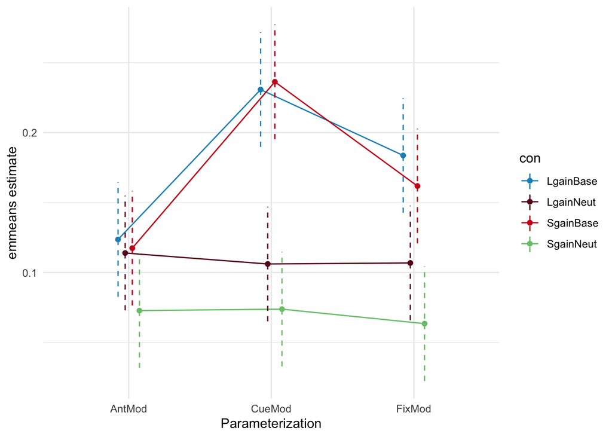

```r
emmip(model_interact, con ~ model, CIs = TRUE, style = "factor",
      dodge = .2, CIarg = list(linetype = "dashed"),
      xlab = "Parameterization", ylab = "emmeans estimate") +
  scale_color_manual(values = pal) + theme_minimal()
```

### 2.1.3 subthreshold

#### 2.1.3.1 HLM Model

```r
model_sub = lmer(median_est ~ fwhm + motion + model + con + (1 | study), data = icc_subthresh, REML = FALSE)
orig_r2_sub = round(as.numeric(r2_nakagawa(model_sub)[2]),2)
tab_model(model_sub)
```

|  | median est |  |  |
| --- | --- | --- | --- |
| Predictors | Estimates | CI | p |
| (Intercept) | 0.13 | 0.10 – 0.16 | **<0.001** |
| fwhm [4.8] | 0.02 | 0.01 – 0.03 | **<0.001** |
| fwhm [6.0] | 0.04 | 0.03 – 0.05 | **<0.001** |
| fwhm [7.2] | 0.05 | 0.04 – 0.06 | **<0.001** |
| fwhm [8.4] | 0.07 | 0.06 – 0.08 | **<0.001** |
| motion [opt2] | 0.00 | -0.01 – 0.01 | 0.870 |
| motion [opt3] | -0.03 | -0.03 – -0.02 | **<0.001** |
| motion [opt4] | -0.03 | -0.03 – -0.02 | **<0.001** |
| model [CueMod] | 0.05 | 0.05 – 0.06 | **<0.001** |
| model [FixMod] | 0.02 | 0.01 – 0.03 | **<0.001** |
| con [LgainNeut] | -0.07 | -0.08 – -0.06 | **<0.001** |
| con [SgainBase] | -0.01 | -0.02 – 0.00 | 0.070 |
| con [SgainNeut] | -0.11 | -0.12 – -0.10 | **<0.001** |
| Random Effects |  |  |  |
| σ<sup>2</sup> | 0.00 |  |  |
| τ<sub>00</sub> <sub>study</sub> | 0.00 |  |  |
| ICC | 0.24 |  |  |
| N <sub>study</sub> | 3 |  |  |
| Observations | 720 |  |  |
| Marginal R<sup>2</sup> / Conditional R<sup>2</sup> | 0.620 / 0.712 |  |  |

```r
model_summary <- compare_models(full_model = model_sub, full_data = icc_subthresh, full_r2 = orig_r2_sub)

kable(model_summary, caption = "Model outputs for Sub-threshold ICC", booktabs = TRUE) %>%
  kable_styling(font_size = 12, position = 'center',html_font = "Times New Roman")
```

Model outputs for Sub-threshold ICC

| Comparison | Full AIC | Full BIC | New AIC | New BIC | χ2 | Orig R2 | New R2 | ∆R2 |
| --- | --- | --- | --- | --- | --- | --- | --- | --- |
| [Full] vs [New - fwhm ] | -2577.599 | -2508.91 | -2360.181 | -2309.81 | 225.418 | 0.62 | 0.51 | 0.11 |
| [Full] vs [New - motion ] | -2577.599 | -2508.91 | -2504.51 | -2449.559 | 79.089 | 0.62 | 0.59 | 0.03 |
| [Full] vs [New - model ] | -2577.599 | -2508.91 | -2376.426 | -2316.895 | 205.173 | 0.62 | 0.52 | 0.1 |
| [Full] vs [New - con ] | -2577.599 | -2508.91 | -1974.202 | -1919.251 | 609.397 | 0.62 | 0.24 | 0.38 |

#### 2.1.3.2 Tukey’s emmeans

```r
perform_emmeans_contrasts(model_sub)
```

[[1]]

Contrast Tukey HSD: FWHM

| contrast | estimate | SE | df | lower.CL | upper.CL | t.ratio | p.value |
| --- | --- | --- | --- | --- | --- | --- | --- |
| fwhm3.6 - fwhm4.8 | -0.0203 | 0.0047 | 729.2 | -0.0331 | -0.0076 | -4.365 | 0.0001 |
| fwhm3.6 - fwhm6.0 | -0.0385 | 0.0047 | 729.2 | -0.0512 | -0.0257 | -8.254 | 0.0000 |
| fwhm3.6 - fwhm7.2 | -0.0539 | 0.0047 | 729.2 | -0.0667 | -0.0412 | -11.575 | 0.0000 |
| fwhm3.6 - fwhm8.4 | -0.0670 | 0.0047 | 729.2 | -0.0797 | -0.0542 | -14.370 | 0.0000 |
| fwhm4.8 - fwhm6.0 | -0.0181 | 0.0047 | 729.2 | -0.0309 | -0.0054 | -3.889 | 0.0010 |
| fwhm4.8 - fwhm7.2 | -0.0336 | 0.0047 | 729.2 | -0.0463 | -0.0209 | -7.210 | 0.0000 |
| fwhm4.8 - fwhm8.4 | -0.0466 | 0.0047 | 729.2 | -0.0594 | -0.0339 | -10.005 | 0.0000 |
| fwhm6.0 - fwhm7.2 | -0.0155 | 0.0047 | 729.2 | -0.0282 | -0.0027 | -3.320 | 0.0084 |
| fwhm6.0 - fwhm8.4 | -0.0285 | 0.0047 | 729.2 | -0.0412 | -0.0158 | -6.116 | 0.0000 |
| fwhm7.2 - fwhm8.4 | -0.0130 | 0.0047 | 729.2 | -0.0258 | -0.0003 | -2.796 | 0.0423 |

[[2]]

Contrast Tukey HSD: Contrast

| contrast | estimate | SE | df | lower.CL | upper.CL | t.ratio | p.value |
| --- | --- | --- | --- | --- | --- | --- | --- |
| LgainBase - LgainNeut | 0.0704 | 0.0042 | 729.2 | 0.0597 | 0.0811 | 16.890 | 0.0000 |
| LgainBase - SgainBase | 0.0075 | 0.0042 | 729.2 | -0.0032 | 0.0182 | 1.799 | 0.2744 |
| LgainBase - SgainNeut | 0.1093 | 0.0042 | 729.2 | 0.0986 | 0.1201 | 26.233 | 0.0000 |
| LgainNeut - SgainBase | -0.0629 | 0.0042 | 729.2 | -0.0736 | -0.0522 | -15.091 | 0.0000 |
| LgainNeut - SgainNeut | 0.0389 | 0.0042 | 729.2 | 0.0282 | 0.0497 | 9.342 | 0.0000 |
| SgainBase - SgainNeut | 0.1018 | 0.0042 | 729.2 | 0.0911 | 0.1126 | 24.433 | 0.0000 |

[[3]]

Contrast Tukey HSD: Motion Corr

| contrast | estimate | SE | df | lower.CL | upper.CL | t.ratio | p.value |
| --- | --- | --- | --- | --- | --- | --- | --- |
| opt1 - opt2 | -0.0007 | 0.0042 | 729.2 | -0.0114 | 0.0101 | -0.1626 | 0.9985 |
| opt1 - opt3 | 0.0264 | 0.0042 | 729.2 | 0.0156 | 0.0371 | 6.3259 | 0.0000 |
| opt1 - opt4 | 0.0264 | 0.0042 | 729.2 | 0.0157 | 0.0371 | 6.3325 | 0.0000 |
| opt2 - opt3 | 0.0270 | 0.0042 | 729.2 | 0.0163 | 0.0378 | 6.4885 | 0.0000 |
| opt2 - opt4 | 0.0271 | 0.0042 | 729.2 | 0.0163 | 0.0378 | 6.4952 | 0.0000 |
| opt3 - opt4 | 0.0000 | 0.0042 | 729.2 | -0.0107 | 0.0108 | 0.0067 | 1.0000 |

[[4]]

Contrast Tukey HSD: Model Type

| contrast | estimate | SE | df | lower.CL | upper.CL | t.ratio | p.value |
| --- | --- | --- | --- | --- | --- | --- | --- |
| AntMod - CueMod | -0.0548 | 0.0036 | 729.2 | -0.0633 | -0.0463 | -15.185 | 0 |
| AntMod - FixMod | -0.0220 | 0.0036 | 729.2 | -0.0305 | -0.0135 | -6.097 | 0 |
| CueMod - FixMod | 0.0328 | 0.0036 | 729.2 | 0.0243 | 0.0413 | 9.088 | 0 |

### 2.1.4 Interaction: Con * Model

#### 2.1.4.1 HLM Model

```r
model_interact = lmer(median_est ~ fwhm + motion + model * con + (1 | study), data = icc_subthresh, REML = FALSE)
tab_model(model_interact)
```

|  | median est |  |  |
| --- | --- | --- | --- |
| Predictors | Estimates | CI | p |
| (Intercept) | 0.10 | 0.07 – 0.13 | **<0.001** |
| fwhm [4.8] | 0.02 | 0.01 – 0.03 | **<0.001** |
| fwhm [6.0] | 0.04 | 0.03 – 0.05 | **<0.001** |
| fwhm [7.2] | 0.05 | 0.05 – 0.06 | **<0.001** |
| fwhm [8.4] | 0.07 | 0.06 – 0.07 | **<0.001** |
| motion [opt2] | 0.00 | -0.01 – 0.01 | 0.835 |
| motion [opt3] | -0.03 | -0.03 – -0.02 | **<0.001** |
| motion [opt4] | -0.03 | -0.03 – -0.02 | **<0.001** |
| model [CueMod] | 0.11 | 0.10 – 0.12 | **<0.001** |
| model [FixMod] | 0.06 | 0.05 – 0.07 | **<0.001** |
| con [LgainNeut] | -0.01 | -0.02 – 0.00 | 0.086 |
| con [SgainBase] | -0.01 | -0.02 – 0.00 | 0.271 |
| con [SgainNeut] | -0.05 | -0.06 – -0.04 | **<0.001** |
| model [CueMod] × con [LgainNeut] | -0.12 | -0.13 – -0.10 | **<0.001** |
| model [FixMod] × con [LgainNeut] | -0.07 | -0.08 – -0.05 | **<0.001** |
| model [CueMod] × con [SgainBase] | 0.01 | -0.00 – 0.03 | 0.141 |
| model [FixMod] × con [SgainBase] | -0.02 | -0.03 – -0.00 | **0.050** |
| model [CueMod] × con [SgainNeut] | -0.11 | -0.12 – -0.09 | **<0.001** |
| model [FixMod] × con [SgainNeut] | -0.07 | -0.09 – -0.05 | **<0.001** |
| Random Effects |  |  |  |
| σ<sup>2</sup> | 0.00 |  |  |
| τ<sub>00</sub> <sub>study</sub> | 0.00 |  |  |
| ICC | 0.34 |  |  |
| N <sub>study</sub> | 3 |  |  |
| Observations | 720 |  |  |
| Marginal R<sup>2</sup> / Conditional R<sup>2</sup> | 0.729 / 0.822 |  |  |

#### 2.1.4.2 Tukey’s emmeans

```r
emmeans(model_interact, ~  "model", by = "con", adjust = "sidak")
```

```
## con = LgainBase:
##  model  emmean     SE   df lower.CL upper.CL
##  AntMod 0.1236 0.0162 5.32  0.06803    0.179
##  CueMod 0.2308 0.0162 5.32  0.17518    0.286
##  FixMod 0.1837 0.0162 5.32  0.12808    0.239
##
## con = LgainNeut:
##  model  emmean     SE   df lower.CL upper.CL
##  AntMod 0.1140 0.0162 5.32  0.05835    0.170
##  CueMod 0.1061 0.0162 5.32  0.05050    0.162
##  FixMod 0.1069 0.0162 5.32  0.05125    0.162
##
## con = SgainBase:
##  model  emmean     SE   df lower.CL upper.CL
##  AntMod 0.1174 0.0162 5.32  0.06183    0.173
##  CueMod 0.2364 0.0162 5.32  0.18073    0.292
##  FixMod 0.1618 0.0162 5.32  0.10623    0.217
##
## con = SgainNeut:
##  model  emmean     SE   df lower.CL upper.CL
##  AntMod 0.0728 0.0162 5.32  0.01718    0.128
##  CueMod 0.0738 0.0162 5.32  0.01823    0.129
##  FixMod 0.0635 0.0162 5.32  0.00786    0.119
##
## Results are averaged over the levels of: fwhm, motion
## Degrees-of-freedom method: kenward-roger
## Confidence level used: 0.95
## Conf-level adjustment: sidak method for 3 estimates
```

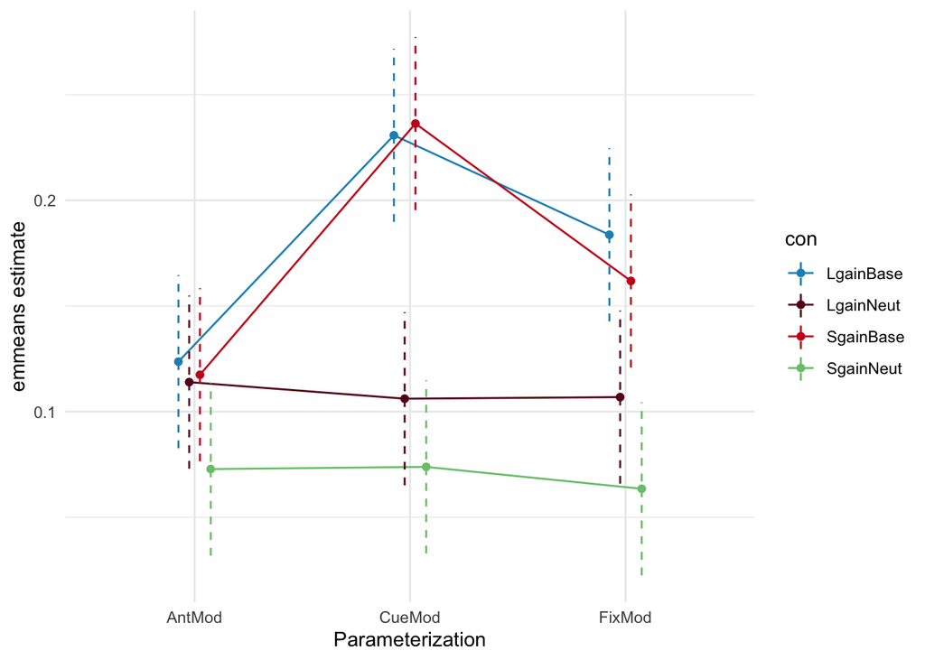

```r
emmip(model_interact, con ~ model, CIs = TRUE, style = "factor",
      dodge = .2, CIarg = list(linetype = "dashed"),
      xlab = "Parameterization", ylab = "emmeans estimate") +
  scale_color_manual(values = pal) + theme_minimal()
```

## 2.2 Between Subject

### 2.2.1 suprathreshold

#### 2.2.1.1 HLM Model

```r
model = lmer(median_est ~ fwhm + motion + model + con + (1 | study), data = bs_suprathresh, REML = FALSE)
orig_r2 = round(as.numeric(r2_nakagawa(model)[2]),2)
tab_model(model)
```

|  | median est |  |  |
| --- | --- | --- | --- |
| Predictors | Estimates | CI | p |
| (Intercept) | 0.15 | 0.11 – 0.20 | **<0.001** |
| fwhm [4.8] | -0.01 | -0.03 – 0.00 | 0.109 |
| fwhm [6.0] | -0.02 | -0.04 – -0.01 | **0.005** |
| fwhm [7.2] | -0.03 | -0.05 – -0.01 | **<0.001** |
| fwhm [8.4] | -0.04 | -0.05 – -0.02 | **<0.001** |
| motion [opt2] | -0.02 | -0.03 – -0.00 | **0.014** |
| motion [opt3] | -0.06 | -0.07 – -0.04 | **<0.001** |
| motion [opt4] | -0.06 | -0.07 – -0.04 | **<0.001** |
| model [CueMod] | 0.08 | 0.07 – 0.10 | **<0.001** |
| model [FixMod] | 0.07 | 0.06 – 0.08 | **<0.001** |
| con [LgainNeut] | -0.12 | -0.13 – -0.11 | **<0.001** |
| con [SgainBase] | -0.02 | -0.03 – -0.00 | **0.027** |
| con [SgainNeut] | -0.14 | -0.15 – -0.12 | **<0.001** |
| Random Effects |  |  |  |
| σ<sup>2</sup> | 0.00 |  |  |
| τ<sub>00</sub> <sub>study</sub> | 0.00 |  |  |
| ICC | 0.24 |  |  |
| N <sub>study</sub> | 3 |  |  |
| Observations | 720 |  |  |
| Marginal R<sup>2</sup> / Conditional R<sup>2</sup> | 0.492 / 0.611 |  |  |

```r
model_summary <- compare_models(full_model = model, full_data = bs_suprathresh, full_r2 = orig_r2)

kable(model_summary, caption = "Model outputs for Supra-threshold Between Subject", booktabs = TRUE) %>%
  kable_styling(font_size = 12, position = 'center',html_font = "Times New Roman")
```

Model outputs for Supra-threshold Between Subject

| Comparison | Full AIC | Full BIC | New AIC | New BIC | χ2 | Orig R2 | New R2 | ∆R2 |
| --- | --- | --- | --- | --- | --- | --- | --- | --- |
| [Full] vs [New - fwhm ] | -1779.547 | -1710.858 | -1762.575 | -1712.203 | 24.972 | 0.49 | 0.48 | 0.01 |
| [Full] vs [New - motion ] | -1779.547 | -1710.858 | -1691.89 | -1636.939 | 93.657 | 0.49 | 0.44 | 0.05 |
| [Full] vs [New - model ] | -1779.547 | -1710.858 | -1598.744 | -1539.214 | 184.803 | 0.49 | 0.38 | 0.11 |
| [Full] vs [New - con ] | -1779.547 | -1710.858 | -1364.429 | -1309.478 | 421.118 | 0.49 | 0.18 | 0.31 |

#### 2.2.1.2 Tukey’s emmeans

```r
perform_emmeans_contrasts(model)
```

[[1]]

Contrast Tukey HSD: FWHM

| contrast | estimate | SE | df | lower.CL | upper.CL | t.ratio | p.value |
| --- | --- | --- | --- | --- | --- | --- | --- |
| fwhm3.6 - fwhm4.8 | 0.0129 | 0.0081 | 729.2 | -0.0093 | 0.0351 | 1.5907 | 0.5039 |
| fwhm3.6 - fwhm6.0 | 0.0226 | 0.0081 | 729.2 | 0.0004 | 0.0448 | 2.7824 | 0.0438 |
| fwhm3.6 - fwhm7.2 | 0.0302 | 0.0081 | 729.2 | 0.0080 | 0.0524 | 3.7266 | 0.0019 |
| fwhm3.6 - fwhm8.4 | 0.0362 | 0.0081 | 729.2 | 0.0140 | 0.0583 | 4.4578 | 0.0001 |
| fwhm4.8 - fwhm6.0 | 0.0097 | 0.0081 | 729.2 | -0.0125 | 0.0318 | 1.1917 | 0.7562 |
| fwhm4.8 - fwhm7.2 | 0.0173 | 0.0081 | 729.2 | -0.0049 | 0.0395 | 2.1360 | 0.2060 |
| fwhm4.8 - fwhm8.4 | 0.0233 | 0.0081 | 729.2 | 0.0011 | 0.0454 | 2.8671 | 0.0345 |
| fwhm6.0 - fwhm7.2 | 0.0077 | 0.0081 | 729.2 | -0.0145 | 0.0298 | 0.9443 | 0.8795 |
| fwhm6.0 - fwhm8.4 | 0.0136 | 0.0081 | 729.2 | -0.0086 | 0.0358 | 1.6754 | 0.4499 |
| fwhm7.2 - fwhm8.4 | 0.0059 | 0.0081 | 729.2 | -0.0163 | 0.0281 | 0.7311 | 0.9492 |

[[2]]

Contrast Tukey HSD: Contrast

| contrast | estimate | SE | df | lower.CL | upper.CL | t.ratio | p.value |
| --- | --- | --- | --- | --- | --- | --- | --- |
| LgainBase - LgainNeut | 0.1208 | 0.0073 | 729.2 | 0.1021 | 0.1395 | 16.647 | 0.0000 |
| LgainBase - SgainBase | 0.0159 | 0.0073 | 729.2 | -0.0028 | 0.0346 | 2.193 | 0.1261 |
| LgainBase - SgainNeut | 0.1366 | 0.0073 | 729.2 | 0.1179 | 0.1553 | 18.828 | 0.0000 |
| LgainNeut - SgainBase | -0.1049 | 0.0073 | 729.2 | -0.1235 | -0.0862 | -14.454 | 0.0000 |
| LgainNeut - SgainNeut | 0.0158 | 0.0073 | 729.2 | -0.0029 | 0.0345 | 2.182 | 0.1293 |
| SgainBase - SgainNeut | 0.1207 | 0.0073 | 729.2 | 0.1020 | 0.1394 | 16.635 | 0.0000 |

[[3]]

Contrast Tukey HSD: Motion Corr

| contrast | estimate | SE | df | lower.CL | upper.CL | t.ratio | p.value |
| --- | --- | --- | --- | --- | --- | --- | --- |
| opt1 - opt2 | 0.0177 | 0.0073 | 729.2 | -0.0010 | 0.0364 | 2.4434 | 0.0700 |
| opt1 - opt3 | 0.0576 | 0.0073 | 729.2 | 0.0389 | 0.0763 | 7.9352 | 0.0000 |
| opt1 - opt4 | 0.0588 | 0.0073 | 729.2 | 0.0401 | 0.0775 | 8.1006 | 0.0000 |
| opt2 - opt3 | 0.0398 | 0.0073 | 729.2 | 0.0212 | 0.0585 | 5.4918 | 0.0000 |
| opt2 - opt4 | 0.0410 | 0.0073 | 729.2 | 0.0224 | 0.0597 | 5.6572 | 0.0000 |
| opt3 - opt4 | 0.0012 | 0.0073 | 729.2 | -0.0175 | 0.0199 | 0.1654 | 0.9984 |

[[4]]

Contrast Tukey HSD: Model Type

| contrast | estimate | SE | df | lower.CL | upper.CL | t.ratio | p.value |
| --- | --- | --- | --- | --- | --- | --- | --- |
| AntMod - CueMod | -0.0850 | 0.0063 | 729.2 | -0.0997 | -0.0702 | -13.53 | 0.0000 |
| AntMod - FixMod | -0.0693 | 0.0063 | 729.2 | -0.0841 | -0.0546 | -11.04 | 0.0000 |
| CueMod - FixMod | 0.0156 | 0.0063 | 729.2 | 0.0009 | 0.0304 | 2.49 | 0.0347 |

### 2.2.2 subthreshold

#### 2.2.2.1 HLM Model

```r
model_sub = lmer(median_est ~ fwhm + motion + model + con + (1 | study), data = bs_subthresh, REML = FALSE)
orig_r2_sub = round(as.numeric(r2_nakagawa(model_sub)[2]),2)
tab_model(model_sub)
```

|  | median est |  |  |
| --- | --- | --- | --- |
| Predictors | Estimates | CI | p |
| (Intercept) | 0.14 | 0.10 – 0.19 | **<0.001** |
| fwhm [4.8] | -0.01 | -0.02 – 0.01 | 0.244 |
| fwhm [6.0] | -0.02 | -0.03 – -0.00 | **0.040** |
| fwhm [7.2] | -0.02 | -0.04 – -0.01 | **0.006** |
| fwhm [8.4] | -0.03 | -0.04 – -0.01 | **0.001** |
| motion [opt2] | -0.02 | -0.04 – -0.01 | **0.001** |
| motion [opt3] | -0.07 | -0.08 – -0.05 | **<0.001** |
| motion [opt4] | -0.07 | -0.08 – -0.05 | **<0.001** |
| model [CueMod] | 0.09 | 0.08 – 0.11 | **<0.001** |
| model [FixMod] | 0.06 | 0.05 – 0.07 | **<0.001** |
| con [LgainNeut] | -0.12 | -0.13 – -0.10 | **<0.001** |
| con [SgainBase] | -0.01 | -0.02 – 0.00 | 0.110 |
| con [SgainNeut] | -0.13 | -0.14 – -0.12 | **<0.001** |
| Random Effects |  |  |  |
| σ<sup>2</sup> | 0.00 |  |  |
| τ<sub>00</sub> <sub>study</sub> | 0.00 |  |  |
| ICC | 0.23 |  |  |
| N <sub>study</sub> | 3 |  |  |
| Observations | 720 |  |  |
| Marginal R<sup>2</sup> / Conditional R<sup>2</sup> | 0.511 / 0.624 |  |  |

```r
model_summary <- compare_models(full_model = model_sub, full_data = bs_subthresh, full_r2 = orig_r2_sub)

kable(model_summary, caption = "Model outputs for Sub-threshold Between Subject", booktabs = TRUE) %>%
  kable_styling(font_size = 12, position = 'center',html_font = "Times New Roman")
```

Model outputs for Sub-threshold Between Subject

| Comparison | Full AIC | Full BIC | New AIC | New BIC | χ2 | Orig R2 | New R2 | ∆R2 |
| --- | --- | --- | --- | --- | --- | --- | --- | --- |
| [Full] vs [New - fwhm ] | -1837.652 | -1768.963 | -1831.977 | -1781.605 | 13.674 | 0.51 | 0.5 | 0.01 |
| [Full] vs [New - motion ] | -1837.652 | -1768.963 | -1721.516 | -1666.565 | 122.136 | 0.51 | 0.44 | 0.07 |
| [Full] vs [New - model ] | -1837.652 | -1768.963 | -1625.986 | -1566.456 | 215.665 | 0.51 | 0.38 | 0.13 |
| [Full] vs [New - con ] | -1837.652 | -1768.963 | -1419.888 | -1364.937 | 423.763 | 0.51 | 0.21 | 0.3 |

#### 2.2.2.2 Tukey’s emmeans

```r
perform_emmeans_contrasts(model_sub)
```

[[1]]

Contrast Tukey HSD: FWHM

| contrast | estimate | SE | df | lower.CL | upper.CL | t.ratio | p.value |
| --- | --- | --- | --- | --- | --- | --- | --- |
| fwhm3.6 - fwhm4.8 | 0.0090 | 0.0078 | 729.2 | -0.0123 | 0.0303 | 1.1569 | 0.7759 |
| fwhm3.6 - fwhm6.0 | 0.0159 | 0.0078 | 729.2 | -0.0054 | 0.0372 | 2.0384 | 0.2487 |
| fwhm3.6 - fwhm7.2 | 0.0212 | 0.0078 | 729.2 | -0.0001 | 0.0425 | 2.7265 | 0.0511 |
| fwhm3.6 - fwhm8.4 | 0.0257 | 0.0078 | 729.2 | 0.0043 | 0.0470 | 3.2925 | 0.0092 |
| fwhm4.8 - fwhm6.0 | 0.0069 | 0.0078 | 729.2 | -0.0144 | 0.0282 | 0.8815 | 0.9037 |
| fwhm4.8 - fwhm7.2 | 0.0122 | 0.0078 | 729.2 | -0.0091 | 0.0335 | 1.5696 | 0.5175 |
| fwhm4.8 - fwhm8.4 | 0.0166 | 0.0078 | 729.2 | -0.0047 | 0.0379 | 2.1356 | 0.2061 |
| fwhm6.0 - fwhm7.2 | 0.0054 | 0.0078 | 729.2 | -0.0159 | 0.0267 | 0.6881 | 0.9591 |
| fwhm6.0 - fwhm8.4 | 0.0098 | 0.0078 | 729.2 | -0.0115 | 0.0311 | 1.2541 | 0.7194 |
| fwhm7.2 - fwhm8.4 | 0.0044 | 0.0078 | 729.2 | -0.0169 | 0.0257 | 0.5660 | 0.9799 |

[[2]]

Contrast Tukey HSD: Contrast

| contrast | estimate | SE | df | lower.CL | upper.CL | t.ratio | p.value |
| --- | --- | --- | --- | --- | --- | --- | --- |
| LgainBase - LgainNeut | 0.1161 | 0.007 | 729.2 | 0.0982 | 0.1341 | 16.666 | 0.0000 |
| LgainBase - SgainBase | 0.0111 | 0.007 | 729.2 | -0.0069 | 0.0290 | 1.587 | 0.3865 |
| LgainBase - SgainNeut | 0.1286 | 0.007 | 729.2 | 0.1107 | 0.1466 | 18.459 | 0.0000 |
| LgainNeut - SgainBase | -0.1051 | 0.007 | 729.2 | -0.1230 | -0.0871 | -15.079 | 0.0000 |
| LgainNeut - SgainNeut | 0.0125 | 0.007 | 729.2 | -0.0054 | 0.0304 | 1.793 | 0.2775 |
| SgainBase - SgainNeut | 0.1176 | 0.007 | 729.2 | 0.0996 | 0.1355 | 16.872 | 0.0000 |

[[3]]

Contrast Tukey HSD: Motion Corr

| contrast | estimate | SE | df | lower.CL | upper.CL | t.ratio | p.value |
| --- | --- | --- | --- | --- | --- | --- | --- |
| opt1 - opt2 | 0.0234 | 0.007 | 729.2 | 0.0054 | 0.0413 | 3.3515 | 0.0047 |
| opt1 - opt3 | 0.0651 | 0.007 | 729.2 | 0.0471 | 0.0830 | 9.3394 | 0.0000 |
| opt1 - opt4 | 0.0661 | 0.007 | 729.2 | 0.0481 | 0.0840 | 9.4829 | 0.0000 |
| opt2 - opt3 | 0.0417 | 0.007 | 729.2 | 0.0238 | 0.0597 | 5.9879 | 0.0000 |
| opt2 - opt4 | 0.0427 | 0.007 | 729.2 | 0.0248 | 0.0607 | 6.1314 | 0.0000 |
| opt3 - opt4 | 0.0010 | 0.007 | 729.2 | -0.0169 | 0.0189 | 0.1435 | 0.9989 |

[[4]]

Contrast Tukey HSD: Model Type

| contrast | estimate | SE | df | lower.CL | upper.CL | t.ratio | p.value |
| --- | --- | --- | --- | --- | --- | --- | --- |
| AntMod - CueMod | -0.0934 | 0.006 | 729.2 | -0.1075 | -0.0792 | -15.472 | 0 |
| AntMod - FixMod | -0.0615 | 0.006 | 729.2 | -0.0757 | -0.0473 | -10.188 | 0 |
| CueMod - FixMod | 0.0319 | 0.006 | 729.2 | 0.0177 | 0.0461 | 5.284 | 0 |

## 2.3 Within Subject

### 2.3.1 suprathreshold

#### 2.3.1.1 HLM Model

```r
model = lmer(median_est ~ fwhm + motion + model + con + (1 | study), data = ws_suprathresh, REML = FALSE)
orig_r2 = round(as.numeric(r2_nakagawa(model)[2]),2)
tab_model(model)
```

|  | median est |  |  |
| --- | --- | --- | --- |
| Predictors | Estimates | CI | p |
| (Intercept) | 0.49 | 0.39 – 0.60 | **<0.001** |
| fwhm [4.8] | -0.11 | -0.14 – -0.09 | **<0.001** |
| fwhm [6.0] | -0.18 | -0.20 – -0.15 | **<0.001** |
| fwhm [7.2] | -0.22 | -0.24 – -0.19 | **<0.001** |
| fwhm [8.4] | -0.25 | -0.27 – -0.22 | **<0.001** |
| motion [opt2] | -0.05 | -0.08 – -0.03 | **<0.001** |
| motion [opt3] | -0.12 | -0.14 – -0.09 | **<0.001** |
| motion [opt4] | -0.12 | -0.14 – -0.10 | **<0.001** |
| model [CueMod] | 0.17 | 0.15 – 0.19 | **<0.001** |
| model [FixMod] | 0.16 | 0.14 – 0.18 | **<0.001** |
| con [LgainNeut] | -0.23 | -0.25 – -0.20 | **<0.001** |
| con [SgainBase] | -0.01 | -0.03 – 0.02 | 0.516 |
| con [SgainNeut] | -0.24 | -0.26 – -0.22 | **<0.001** |
| Random Effects |  |  |  |
| σ<sup>2</sup> | 0.01 |  |  |
| τ<sub>00</sub> <sub>study</sub> | 0.01 |  |  |
| ICC | 0.38 |  |  |
| N <sub>study</sub> | 3 |  |  |
| Observations | 720 |  |  |
| Marginal R<sup>2</sup> / Conditional R<sup>2</sup> | 0.586 / 0.743 |  |  |

```r
model_summary <- compare_models(full_model = model, full_data = ws_suprathresh, full_r2 = orig_r2)

kable(model_summary, caption = "Model outputs for Supra-threshold Within Subject", booktabs = TRUE) %>%
  kable_styling(font_size = 12, position = 'center',html_font = "Times New Roman")
```

Model outputs for Supra-threshold Within Subject

| Comparison | Full AIC | Full BIC | New AIC | New BIC | χ2 | Orig R2 | New R2 | ∆R2 |
| --- | --- | --- | --- | --- | --- | --- | --- | --- |
| [Full] vs [New - fwhm ] | -1042.404 | -973.715 | -714.212 | -663.84 | 336.192 | 0.59 | 0.43 | 0.16 |
| [Full] vs [New - motion ] | -1042.404 | -973.715 | -922.188 | -867.237 | 126.216 | 0.59 | 0.54 | 0.0499999999999999 |
| [Full] vs [New - model ] | -1042.404 | -973.715 | -771.735 | -712.205 | 274.669 | 0.59 | 0.47 | 0.12 |
| [Full] vs [New - con ] | -1042.404 | -973.715 | -541.131 | -486.18 | 507.273 | 0.59 | 0.32 | 0.27 |

#### 2.3.1.2 Tukey’s emmeans

```r
perform_emmeans_contrasts(model)
```

[[1]]

Contrast Tukey HSD: FWHM

| contrast | estimate | SE | df | lower.CL | upper.CL | t.ratio | p.value |
| --- | --- | --- | --- | --- | --- | --- | --- |
| fwhm3.6 - fwhm4.8 | 0.1124 | 0.0135 | 729.2 | 0.0755 | 0.1494 | 8.319 | 0.0000 |
| fwhm3.6 - fwhm6.0 | 0.1778 | 0.0135 | 729.2 | 0.1409 | 0.2148 | 13.158 | 0.0000 |
| fwhm3.6 - fwhm7.2 | 0.2186 | 0.0135 | 729.2 | 0.1817 | 0.2556 | 16.176 | 0.0000 |
| fwhm3.6 - fwhm8.4 | 0.2455 | 0.0135 | 729.2 | 0.2086 | 0.2825 | 18.167 | 0.0000 |
| fwhm4.8 - fwhm6.0 | 0.0654 | 0.0135 | 729.2 | 0.0285 | 0.1024 | 4.840 | 0.0000 |
| fwhm4.8 - fwhm7.2 | 0.1062 | 0.0135 | 729.2 | 0.0692 | 0.1431 | 7.857 | 0.0000 |
| fwhm4.8 - fwhm8.4 | 0.1331 | 0.0135 | 729.2 | 0.0961 | 0.1701 | 9.849 | 0.0000 |
| fwhm6.0 - fwhm7.2 | 0.0408 | 0.0135 | 729.2 | 0.0038 | 0.0777 | 3.017 | 0.0221 |
| fwhm6.0 - fwhm8.4 | 0.0677 | 0.0135 | 729.2 | 0.0307 | 0.1047 | 5.009 | 0.0000 |
| fwhm7.2 - fwhm8.4 | 0.0269 | 0.0135 | 729.2 | -0.0100 | 0.0639 | 1.992 | 0.2710 |

[[2]]

Contrast Tukey HSD: Contrast

| contrast | estimate | SE | df | lower.CL | upper.CL | t.ratio | p.value |
| --- | --- | --- | --- | --- | --- | --- | --- |
| LgainBase - LgainNeut | 0.2266 | 0.0121 | 729.2 | 0.1955 | 0.2577 | 18.7444 | 0.0000 |
| LgainBase - SgainBase | 0.0078 | 0.0121 | 729.2 | -0.0233 | 0.0389 | 0.6439 | 0.9177 |
| LgainBase - SgainNeut | 0.2410 | 0.0121 | 729.2 | 0.2099 | 0.2722 | 19.9398 | 0.0000 |
| LgainNeut - SgainBase | -0.2188 | 0.0121 | 729.2 | -0.2499 | -0.1877 | -18.1005 | 0.0000 |
| LgainNeut - SgainNeut | 0.0144 | 0.0121 | 729.2 | -0.0167 | 0.0456 | 1.1954 | 0.6300 |
| SgainBase - SgainNeut | 0.2333 | 0.0121 | 729.2 | 0.2021 | 0.2644 | 19.2959 | 0.0000 |

[[3]]

Contrast Tukey HSD: Motion Corr

| contrast | estimate | SE | df | lower.CL | upper.CL | t.ratio | p.value |
| --- | --- | --- | --- | --- | --- | --- | --- |
| opt1 - opt2 | 0.0516 | 0.0121 | 729.2 | 0.0205 | 0.0828 | 4.2714 | 0.0001 |
| opt1 - opt3 | 0.1181 | 0.0121 | 729.2 | 0.0870 | 0.1493 | 9.7741 | 0.0000 |
| opt1 - opt4 | 0.1187 | 0.0121 | 729.2 | 0.0876 | 0.1499 | 9.8237 | 0.0000 |
| opt2 - opt3 | 0.0665 | 0.0121 | 729.2 | 0.0354 | 0.0976 | 5.5027 | 0.0000 |
| opt2 - opt4 | 0.0671 | 0.0121 | 729.2 | 0.0360 | 0.0982 | 5.5523 | 0.0000 |
| opt3 - opt4 | 0.0006 | 0.0121 | 729.2 | -0.0305 | 0.0317 | 0.0496 | 1.0000 |

[[4]]

Contrast Tukey HSD: Model Type

| contrast | estimate | SE | df | lower.CL | upper.CL | t.ratio | p.value |
| --- | --- | --- | --- | --- | --- | --- | --- |
| AntMod - CueMod | -0.1689 | 0.0105 | 729.2 | -0.1935 | -0.1443 | -16.1316 | 0.0000 |
| AntMod - FixMod | -0.1597 | 0.0105 | 729.2 | -0.1843 | -0.1351 | -15.2524 | 0.0000 |
| CueMod - FixMod | 0.0092 | 0.0105 | 729.2 | -0.0154 | 0.0338 | 0.8792 | 0.6536 |

### 2.3.2 subthreshold

#### 2.3.2.1 HLM Model

```r
model_sub = lmer(median_est ~ fwhm + motion + model + con + (1 | study), data = ws_subthresh, REML = FALSE)
orig_r2_sub = round(as.numeric(r2_nakagawa(model_sub)[2]),2)
tab_model(model_sub)
```

|  | median est |  |  |
| --- | --- | --- | --- |
| Predictors | Estimates | CI | p |
| (Intercept) | 0.84 | 0.67 – 1.02 | **<0.001** |
| fwhm [4.8] | -0.19 | -0.23 – -0.15 | **<0.001** |
| fwhm [6.0] | -0.30 | -0.34 – -0.26 | **<0.001** |
| fwhm [7.2] | -0.37 | -0.41 – -0.33 | **<0.001** |
| fwhm [8.4] | -0.41 | -0.46 – -0.37 | **<0.001** |
| motion [opt2] | -0.11 | -0.15 – -0.07 | **<0.001** |
| motion [opt3] | -0.22 | -0.26 – -0.18 | **<0.001** |
| motion [opt4] | -0.22 | -0.26 – -0.18 | **<0.001** |
| model [CueMod] | 0.26 | 0.22 – 0.29 | **<0.001** |
| model [FixMod] | 0.25 | 0.21 – 0.28 | **<0.001** |
| con [LgainNeut] | -0.37 | -0.41 – -0.33 | **<0.001** |
| con [SgainBase] | -0.02 | -0.06 – 0.02 | 0.408 |
| con [SgainNeut] | -0.39 | -0.43 – -0.35 | **<0.001** |
| Random Effects |  |  |  |
| σ<sup>2</sup> | 0.04 |  |  |
| τ<sub>00</sub> <sub>study</sub> | 0.02 |  |  |
| ICC | 0.38 |  |  |
| N <sub>study</sub> | 3 |  |  |
| Observations | 720 |  |  |
| Marginal R<sup>2</sup> / Conditional R<sup>2</sup> | 0.578 / 0.737 |  |  |

```r
model_summary <- compare_models(full_model = model_sub, full_data = ws_subthresh, full_r2 = orig_r2_sub)

kable(model_summary, caption = "Model outputs for Sub-threshold Within Subject", booktabs = TRUE) %>%
  kable_styling(font_size = 12, position = 'center',html_font = "Times New Roman")
```

Model outputs for Sub-threshold Within Subject

| Comparison | Full AIC | Full BIC | New AIC | New BIC | χ2 | Orig R2 | New R2 | ∆R2 |
| --- | --- | --- | --- | --- | --- | --- | --- | --- |
| [Full] vs [New - fwhm ] | -306.2 | -237.511 | 28.748 | 79.12 | 342.947 | 0.58 | 0.42 | 0.16 |
| [Full] vs [New - motion ] | -306.2 | -237.511 | -159.219 | -104.268 | 152.98 | 0.58 | 0.52 | 0.0599999999999999 |
| [Full] vs [New - model ] | -306.2 | -237.511 | -74.333 | -14.803 | 235.866 | 0.58 | 0.48 | 0.1 |
| [Full] vs [New - con ] | -306.2 | -237.511 | 171.696 | 226.647 | 483.895 | 0.58 | 0.33 | 0.25 |

#### 2.3.2.2 Tukey’s emmeans

```r
perform_emmeans_contrasts(model_sub)
```

[[1]]

Contrast Tukey HSD: FWHM

| contrast | estimate | SE | df | lower.CL | upper.CL | t.ratio | p.value |
| --- | --- | --- | --- | --- | --- | --- | --- |
| fwhm3.6 - fwhm4.8 | 0.1904 | 0.0225 | 729.2 | 0.1288 | 0.2520 | 8.448 | 0.0000 |
| fwhm3.6 - fwhm6.0 | 0.3003 | 0.0225 | 729.2 | 0.2387 | 0.3619 | 13.327 | 0.0000 |
| fwhm3.6 - fwhm7.2 | 0.3690 | 0.0225 | 729.2 | 0.3074 | 0.4307 | 16.376 | 0.0000 |
| fwhm3.6 - fwhm8.4 | 0.4148 | 0.0225 | 729.2 | 0.3532 | 0.4764 | 18.407 | 0.0000 |
| fwhm4.8 - fwhm6.0 | 0.1099 | 0.0225 | 729.2 | 0.0483 | 0.1716 | 4.879 | 0.0000 |
| fwhm4.8 - fwhm7.2 | 0.1786 | 0.0225 | 729.2 | 0.1170 | 0.2403 | 7.928 | 0.0000 |
| fwhm4.8 - fwhm8.4 | 0.2244 | 0.0225 | 729.2 | 0.1628 | 0.2860 | 9.959 | 0.0000 |
| fwhm6.0 - fwhm7.2 | 0.0687 | 0.0225 | 729.2 | 0.0071 | 0.1303 | 3.049 | 0.0201 |
| fwhm6.0 - fwhm8.4 | 0.1145 | 0.0225 | 729.2 | 0.0529 | 0.1761 | 5.080 | 0.0000 |
| fwhm7.2 - fwhm8.4 | 0.0458 | 0.0225 | 729.2 | -0.0159 | 0.1074 | 2.031 | 0.2521 |

[[2]]

Contrast Tukey HSD: Contrast

| contrast | estimate | SE | df | lower.CL | upper.CL | t.ratio | p.value |
| --- | --- | --- | --- | --- | --- | --- | --- |
| LgainBase - LgainNeut | 0.3670 | 0.0202 | 729.2 | 0.3151 | 0.4189 | 18.2076 | 0.0000 |
| LgainBase - SgainBase | 0.0166 | 0.0202 | 729.2 | -0.0353 | 0.0685 | 0.8214 | 0.8444 |
| LgainBase - SgainNeut | 0.3914 | 0.0202 | 729.2 | 0.3395 | 0.4433 | 19.4199 | 0.0000 |
| LgainNeut - SgainBase | -0.3504 | 0.0202 | 729.2 | -0.4023 | -0.2985 | -17.3863 | 0.0000 |
| LgainNeut - SgainNeut | 0.0244 | 0.0202 | 729.2 | -0.0275 | 0.0763 | 1.2122 | 0.6193 |
| SgainBase - SgainNeut | 0.3749 | 0.0202 | 729.2 | 0.3230 | 0.4268 | 18.5985 | 0.0000 |

[[3]]

Contrast Tukey HSD: Motion Corr

| contrast | estimate | SE | df | lower.CL | upper.CL | t.ratio | p.value |
| --- | --- | --- | --- | --- | --- | --- | --- |
| opt1 - opt2 | 0.1081 | 0.0202 | 729.2 | 0.0562 | 0.1600 | 5.3643 | 0.0000 |
| opt1 - opt3 | 0.2198 | 0.0202 | 729.2 | 0.1679 | 0.2717 | 10.9031 | 0.0000 |
| opt1 - opt4 | 0.2242 | 0.0202 | 729.2 | 0.1723 | 0.2761 | 11.1253 | 0.0000 |
| opt2 - opt3 | 0.1116 | 0.0202 | 729.2 | 0.0597 | 0.1635 | 5.5388 | 0.0000 |
| opt2 - opt4 | 0.1161 | 0.0202 | 729.2 | 0.0642 | 0.1680 | 5.7610 | 0.0000 |
| opt3 - opt4 | 0.0045 | 0.0202 | 729.2 | -0.0474 | 0.0564 | 0.2222 | 0.9961 |

[[4]]

Contrast Tukey HSD: Model Type

| contrast | estimate | SE | df | lower.CL | upper.CL | t.ratio | p.value |
| --- | --- | --- | --- | --- | --- | --- | --- |
| AntMod - CueMod | -0.2554 | 0.0175 | 729.2 | -0.2964 | -0.2144 | -14.6340 | 0.0000 |
| AntMod - FixMod | -0.2453 | 0.0175 | 729.2 | -0.2863 | -0.2043 | -14.0510 | 0.0000 |
| CueMod - FixMod | 0.0102 | 0.0175 | 729.2 | -0.0308 | 0.0512 | 0.5829 | 0.8293 |

## 2.4 Similarity

### 2.4.1 Jaccard

#### 2.4.1.1 HLM Model

```r
model = lmer(jaccard ~ fwhm + motion + model + con + (1 | study), data = similarity_df, REML = FALSE)
orig_r2 = round(as.numeric(r2_nakagawa(model)[2]),2)
tab_model(model)
```

|  | jaccard |  |  |
| --- | --- | --- | --- |
| Predictors | Estimates | CI | p |
| (Intercept) | 0.29 | 0.20 – 0.38 | **<0.001** |
| fwhm [4.8] | 0.04 | 0.02 – 0.06 | **<0.001** |
| fwhm [6] | 0.07 | 0.05 – 0.10 | **<0.001** |
| fwhm [7.2] | 0.10 | 0.08 – 0.12 | **<0.001** |
| fwhm [8.4] | 0.12 | 0.10 – 0.14 | **<0.001** |
| motion [opt2] | 0.04 | 0.02 – 0.06 | **<0.001** |
| motion [opt3] | 0.03 | 0.01 – 0.05 | **0.002** |
| motion [opt4] | 0.04 | 0.02 – 0.06 | **<0.001** |
| model [CueMod] | 0.00 | -0.01 – 0.02 | 0.637 |
| model [FixMod] | 0.10 | 0.08 – 0.12 | **<0.001** |
| con [LgainNeut] | -0.06 | -0.08 – -0.04 | **<0.001** |
| con [SgainBase] | -0.04 | -0.06 – -0.02 | **<0.001** |
| con [SgainNeut] | -0.24 | -0.26 – -0.22 | **<0.001** |
| Random Effects |  |  |  |
| σ<sup>2</sup> | 0.01 |  |  |
| τ<sub>00</sub> <sub>study</sub> | 0.01 |  |  |
| ICC | 0.36 |  |  |
| N <sub>study</sub> | 3 |  |  |
| Observations | 720 |  |  |
| Marginal R<sup>2</sup> / Conditional R<sup>2</sup> | 0.465 / 0.660 |  |  |

```r
model_summary <- compare_models(full_model = model, full_data = similarity_df, full_r2 = orig_r2)

kable(model_summary, caption = "Model outputs for Jaccard Similarity", booktabs = TRUE) %>%
  kable_styling(font_size = 12, position = 'center',html_font = "Times New Roman")
```

Model outputs for Jaccard Similarity

| Comparison | Full AIC | Full BIC | New AIC | New BIC | χ2 | Orig R2 | New R2 | ∆R2 |
| --- | --- | --- | --- | --- | --- | --- | --- | --- |
| [Full] vs [New - fwhm ] | -1275.711 | -1207.023 | -1159.697 | -1109.325 | 124.015 | 0.47 | 0.4 | 0.07 |
| [Full] vs [New - motion ] | -1275.711 | -1207.023 | -1260.08 | -1205.129 | 21.632 | 0.47 | 0.45 | 0.02 |
| [Full] vs [New - model ] | -1275.711 | -1207.023 | -1130.778 | -1071.248 | 148.933 | 0.47 | 0.39 | 0.08 |
| [Full] vs [New - con ] | -1275.711 | -1207.023 | -813.813 | -758.862 | 467.899 | 0.47 | 0.15 | 0.32 |

#### 2.4.1.2 Tukey’s emmeans

```r
perform_emmeans_contrasts(model)
```

[[1]]

Contrast Tukey HSD: FWHM

| contrast | estimate | SE | df | lower.CL | upper.CL | t.ratio | p.value |
| --- | --- | --- | --- | --- | --- | --- | --- |
| fwhm3.6 - fwhm4.8 | -0.0421 | 0.0115 | 729.2 | -0.0736 | -0.0107 | -3.665 | 0.0025 |
| fwhm3.6 - fwhm6 | -0.0745 | 0.0115 | 729.2 | -0.1059 | -0.0430 | -6.478 | 0.0000 |
| fwhm3.6 - fwhm7.2 | -0.0989 | 0.0115 | 729.2 | -0.1304 | -0.0675 | -8.607 | 0.0000 |
| fwhm3.6 - fwhm8.4 | -0.1181 | 0.0115 | 729.2 | -0.1495 | -0.0867 | -10.274 | 0.0000 |
| fwhm4.8 - fwhm6 | -0.0323 | 0.0115 | 729.2 | -0.0638 | -0.0009 | -2.813 | 0.0403 |
| fwhm4.8 - fwhm7.2 | -0.0568 | 0.0115 | 729.2 | -0.0882 | -0.0254 | -4.942 | 0.0000 |
| fwhm4.8 - fwhm8.4 | -0.0760 | 0.0115 | 729.2 | -0.1074 | -0.0445 | -6.610 | 0.0000 |
| fwhm6 - fwhm7.2 | -0.0245 | 0.0115 | 729.2 | -0.0559 | 0.0070 | -2.130 | 0.2085 |
| fwhm6 - fwhm8.4 | -0.0436 | 0.0115 | 729.2 | -0.0751 | -0.0122 | -3.797 | 0.0015 |
| fwhm7.2 - fwhm8.4 | -0.0192 | 0.0115 | 729.2 | -0.0506 | 0.0123 | -1.667 | 0.4550 |

[[2]]

Contrast Tukey HSD: Contrast

| contrast | estimate | SE | df | lower.CL | upper.CL | t.ratio | p.value |
| --- | --- | --- | --- | --- | --- | --- | --- |
| LgainBase - LgainNeut | 0.0555 | 0.0103 | 729.2 | 0.0290 | 0.0820 | 5.399 | 0.0000 |
| LgainBase - SgainBase | 0.0383 | 0.0103 | 729.2 | 0.0118 | 0.0648 | 3.725 | 0.0012 |
| LgainBase - SgainNeut | 0.2400 | 0.0103 | 729.2 | 0.2136 | 0.2665 | 23.345 | 0.0000 |
| LgainNeut - SgainBase | -0.0172 | 0.0103 | 729.2 | -0.0437 | 0.0093 | -1.674 | 0.3384 |
| LgainNeut - SgainNeut | 0.1845 | 0.0103 | 729.2 | 0.1580 | 0.2110 | 17.947 | 0.0000 |
| SgainBase - SgainNeut | 0.2017 | 0.0103 | 729.2 | 0.1753 | 0.2282 | 19.621 | 0.0000 |

[[3]]

Contrast Tukey HSD: Motion Corr

| contrast | estimate | SE | df | lower.CL | upper.CL | t.ratio | p.value |
| --- | --- | --- | --- | --- | --- | --- | --- |
| opt1 - opt2 | -0.0431 | 0.0103 | 729.2 | -0.0696 | -0.0167 | -4.1954 | 0.0002 |
| opt1 - opt3 | -0.0312 | 0.0103 | 729.2 | -0.0577 | -0.0048 | -3.0378 | 0.0132 |
| opt1 - opt4 | -0.0389 | 0.0103 | 729.2 | -0.0653 | -0.0124 | -3.7808 | 0.0010 |
| opt2 - opt3 | 0.0119 | 0.0103 | 729.2 | -0.0146 | 0.0384 | 1.1576 | 0.6538 |
| opt2 - opt4 | 0.0043 | 0.0103 | 729.2 | -0.0222 | 0.0307 | 0.4146 | 0.9760 |
| opt3 - opt4 | -0.0076 | 0.0103 | 729.2 | -0.0341 | 0.0188 | -0.7430 | 0.8796 |

[[4]]

Contrast Tukey HSD: Model Type

| contrast | estimate | SE | df | lower.CL | upper.CL | t.ratio | p.value |
| --- | --- | --- | --- | --- | --- | --- | --- |
| AntMod - CueMod | -0.0042 | 0.0089 | 729.2 | -0.0251 | 0.0167 | -0.4679 | 0.8864 |
| AntMod - FixMod | -0.1004 | 0.0089 | 729.2 | -0.1213 | -0.0795 | -11.2750 | 0.0000 |
| CueMod - FixMod | -0.0962 | 0.0089 | 729.2 | -0.1171 | -0.0753 | -10.8072 | 0.0000 |

### 2.4.2 Interaction: Con * Model

#### 2.4.2.1 HLM Model

```r
model_interact = lmer(jaccard ~ fwhm + motion + model * con + (1 | study),
                      data = similarity_df, REML = FALSE)
tab_model(model_interact)
```

|  | jaccard |  |  |
| --- | --- | --- | --- |
| Predictors | Estimates | CI | p |
| (Intercept) | 0.26 | 0.17 – 0.35 | **<0.001** |
| fwhm [4.8] | 0.04 | 0.02 – 0.06 | **<0.001** |
| fwhm [6] | 0.07 | 0.06 – 0.09 | **<0.001** |
| fwhm [7.2] | 0.10 | 0.08 – 0.12 | **<0.001** |
| fwhm [8.4] | 0.12 | 0.10 – 0.14 | **<0.001** |
| motion [opt2] | 0.04 | 0.03 – 0.06 | **<0.001** |
| motion [opt3] | 0.03 | 0.01 – 0.05 | **<0.001** |
| motion [opt4] | 0.04 | 0.02 – 0.06 | **<0.001** |
| model [CueMod] | -0.02 | -0.05 – 0.01 | 0.199 |
| model [FixMod] | 0.21 | 0.19 – 0.24 | **<0.001** |
| con [LgainNeut] | 0.02 | -0.01 – 0.05 | 0.234 |
| con [SgainBase] | -0.05 | -0.08 – -0.02 | **<0.001** |
| con [SgainNeut] | -0.18 | -0.21 – -0.15 | **<0.001** |
| model [CueMod] × con [LgainNeut] | 0.00 | -0.04 – 0.04 | 0.907 |
| model [FixMod] × con [LgainNeut] | -0.22 | -0.26 – -0.18 | **<0.001** |
| model [CueMod] × con [SgainBase] | 0.05 | 0.01 – 0.09 | **0.027** |
| model [FixMod] × con [SgainBase] | -0.00 | -0.04 – 0.04 | 0.942 |
| model [CueMod] × con [SgainNeut] | 0.04 | 0.00 – 0.08 | **0.035** |
| model [FixMod] × con [SgainNeut] | -0.23 | -0.27 – -0.19 | **<0.001** |
| Random Effects |  |  |  |
| σ<sup>2</sup> | 0.01 |  |  |
| τ<sub>00</sub> <sub>study</sub> | 0.01 |  |  |
| ICC | 0.46 |  |  |
| N <sub>study</sub> | 3 |  |  |
| Observations | 720 |  |  |
| Marginal R<sup>2</sup> / Conditional R<sup>2</sup> | 0.573 / 0.768 |  |  |

#### 2.4.2.2 Tukey’s emmeans

```r
emmeans(model_interact, ~  "model", by = "con", adjust = "sidak")
```

```
## con = LgainBase:
##  model  emmean     SE df lower.CL upper.CL
##  AntMod  0.356 0.0528  5   0.1706    0.542
##  CueMod  0.338 0.0528  5   0.1519    0.523
##  FixMod  0.571 0.0528  5   0.3848    0.756
##
## con = LgainNeut:
##  model  emmean     SE df lower.CL upper.CL
##  AntMod  0.374 0.0528  5   0.1880    0.560
##  CueMod  0.357 0.0528  5   0.1716    0.543
##  FixMod  0.367 0.0528  5   0.1811    0.553
##
## con = SgainBase:
##  model  emmean     SE df lower.CL upper.CL
##  AntMod  0.303 0.0528  5   0.1176    0.489
##  CueMod  0.330 0.0528  5   0.1445    0.516
##  FixMod  0.516 0.0528  5   0.3303    0.702
##
## con = SgainNeut:
##  model  emmean     SE df lower.CL upper.CL
##  AntMod  0.179 0.0528  5  -0.0064    0.365
##  CueMod  0.204 0.0528  5   0.0185    0.390
##  FixMod  0.161 0.0528  5  -0.0248    0.347
##
## Results are averaged over the levels of: fwhm, motion
## Degrees-of-freedom method: kenward-roger
## Confidence level used: 0.95
## Conf-level adjustment: sidak method for 3 estimates
```

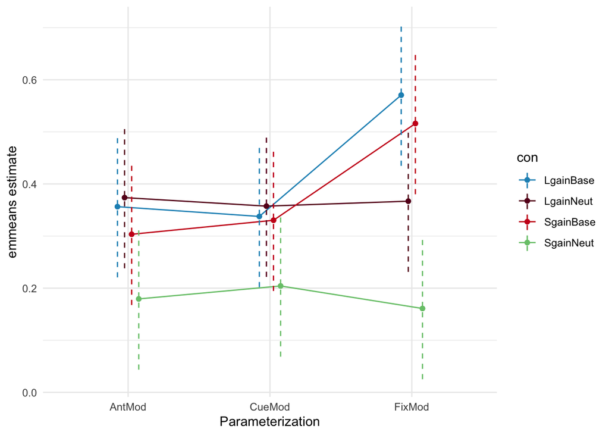

```r
emmip(model_interact, con ~ model, CIs = TRUE, style = "factor",
      dodge = .2, CIarg = list(linetype = "dashed"),
      xlab = "Parameterization", ylab = "emmeans estimate") +
  scale_color_manual(values = pal) + theme_minimal()
```

### 2.4.3 Spearman

#### 2.4.3.1 HLM Model

```r
model = lmer(spearman ~ fwhm + motion + model + con + (1 | study), data = similarity_df, REML = FALSE)
orig_r2 = round(as.numeric(r2_nakagawa(model)[2]),2)
tab_model(model)
```

|  | spearman |  |  |
| --- | --- | --- | --- |
| Predictors | Estimates | CI | p |
| (Intercept) | 0.82 | 0.76 – 0.87 | **<0.001** |
| fwhm [4.8] | 0.04 | 0.03 – 0.06 | **<0.001** |
| fwhm [6] | 0.07 | 0.05 – 0.08 | **<0.001** |
| fwhm [7.2] | 0.09 | 0.07 – 0.10 | **<0.001** |
| fwhm [8.4] | 0.10 | 0.08 – 0.12 | **<0.001** |
| motion [opt2] | 0.03 | 0.02 – 0.04 | **<0.001** |
| motion [opt3] | 0.05 | 0.03 – 0.06 | **<0.001** |
| motion [opt4] | 0.05 | 0.04 – 0.06 | **<0.001** |
| model [CueMod] | -0.01 | -0.02 – 0.00 | 0.117 |
| model [FixMod] | -0.01 | -0.02 – 0.01 | 0.307 |
| con [LgainNeut] | -0.15 | -0.16 – -0.14 | **<0.001** |
| con [SgainBase] | -0.01 | -0.03 – -0.00 | **0.046** |
| con [SgainNeut] | -0.32 | -0.34 – -0.31 | **<0.001** |
| Random Effects |  |  |  |
| σ<sup>2</sup> | 0.00 |  |  |
| τ<sub>00</sub> <sub>study</sub> | 0.00 |  |  |
| ICC | 0.33 |  |  |
| N <sub>study</sub> | 3 |  |  |
| Observations | 720 |  |  |
| Marginal R<sup>2</sup> / Conditional R<sup>2</sup> | 0.742 / 0.827 |  |  |

```r
model_summary <- compare_models(full_model = model, full_data = similarity_df, full_r2 = orig_r2)

kable(model_summary, caption = "Model outputs for Spearman rho", booktabs = TRUE) %>%
  kable_styling(font_size = 12, position = 'center',html_font = "Times New Roman")
```

Model outputs for Spearman rho

| Comparison | Full AIC | Full BIC | New AIC | New BIC | χ2 | Orig R2 | New R2 | ∆R2 |
| --- | --- | --- | --- | --- | --- | --- | --- | --- |
| [Full] vs [New - fwhm ] | -1825.71 | -1757.021 | -1649.618 | -1599.246 | 184.092 | 0.74 | 0.69 | 0.05 |
| [Full] vs [New - motion ] | -1825.71 | -1757.021 | -1770.293 | -1715.342 | 61.417 | 0.74 | 0.73 | 0.01 |
| [Full] vs [New - model ] | -1825.71 | -1757.021 | -1827.174 | -1767.644 | 2.536 | 0.74 | 0.74 | 0 |
| [Full] vs [New - con ] | -1825.71 | -1757.021 | -690.616 | -635.665 | 1141.094 | 0.74 | 0.07 | 0.67 |

#### 2.4.3.2 Tukey’s emmeans

```r
perform_emmeans_contrasts(model)
```

[[1]]

Contrast Tukey HSD: FWHM

| contrast | estimate | SE | df | lower.CL | upper.CL | t.ratio | p.value |
| --- | --- | --- | --- | --- | --- | --- | --- |
| fwhm3.6 - fwhm4.8 | -0.0405 | 0.0078 | 729.2 | -0.0620 | -0.0190 | -5.162 | 0.0000 |
| fwhm3.6 - fwhm6 | -0.0681 | 0.0078 | 729.2 | -0.0896 | -0.0467 | -8.682 | 0.0000 |
| fwhm3.6 - fwhm7.2 | -0.0869 | 0.0078 | 729.2 | -0.1084 | -0.0654 | -11.072 | 0.0000 |
| fwhm3.6 - fwhm8.4 | -0.0999 | 0.0078 | 729.2 | -0.1213 | -0.0784 | -12.726 | 0.0000 |
| fwhm4.8 - fwhm6 | -0.0276 | 0.0078 | 729.2 | -0.0491 | -0.0062 | -3.520 | 0.0042 |
| fwhm4.8 - fwhm7.2 | -0.0464 | 0.0078 | 729.2 | -0.0678 | -0.0249 | -5.910 | 0.0000 |
| fwhm4.8 - fwhm8.4 | -0.0594 | 0.0078 | 729.2 | -0.0808 | -0.0379 | -7.564 | 0.0000 |
| fwhm6 - fwhm7.2 | -0.0188 | 0.0078 | 729.2 | -0.0402 | 0.0027 | -2.390 | 0.1190 |
| fwhm6 - fwhm8.4 | -0.0317 | 0.0078 | 729.2 | -0.0532 | -0.0103 | -4.045 | 0.0006 |
| fwhm7.2 - fwhm8.4 | -0.0130 | 0.0078 | 729.2 | -0.0344 | 0.0085 | -1.654 | 0.4633 |

[[2]]

Contrast Tukey HSD: Contrast

| contrast | estimate | SE | df | lower.CL | upper.CL | t.ratio | p.value |
| --- | --- | --- | --- | --- | --- | --- | --- |
| LgainBase - LgainNeut | 0.1512 | 0.007 | 729.2 | 0.1331 | 0.1693 | 21.538 | 0.000 |
| LgainBase - SgainBase | 0.0139 | 0.007 | 729.2 | -0.0042 | 0.0320 | 1.981 | 0.196 |
| LgainBase - SgainNeut | 0.3233 | 0.007 | 729.2 | 0.3052 | 0.3413 | 46.053 | 0.000 |
| LgainNeut - SgainBase | -0.1373 | 0.007 | 729.2 | -0.1554 | -0.1192 | -19.557 | 0.000 |
| LgainNeut - SgainNeut | 0.1721 | 0.007 | 729.2 | 0.1540 | 0.1902 | 24.515 | 0.000 |
| SgainBase - SgainNeut | 0.3094 | 0.007 | 729.2 | 0.2913 | 0.3274 | 44.072 | 0.000 |

[[3]]

Contrast Tukey HSD: Motion Corr

| contrast | estimate | SE | df | lower.CL | upper.CL | t.ratio | p.value |
| --- | --- | --- | --- | --- | --- | --- | --- |
| opt1 - opt2 | -0.0302 | 0.007 | 729.2 | -0.0483 | -0.0121 | -4.3001 | 0.0001 |
| opt1 - opt3 | -0.0461 | 0.007 | 729.2 | -0.0642 | -0.0281 | -6.5714 | 0.0000 |
| opt1 - opt4 | -0.0501 | 0.007 | 729.2 | -0.0682 | -0.0320 | -7.1353 | 0.0000 |
| opt2 - opt3 | -0.0159 | 0.007 | 729.2 | -0.0340 | 0.0021 | -2.2713 | 0.1057 |
| opt2 - opt4 | -0.0199 | 0.007 | 729.2 | -0.0380 | -0.0018 | -2.8352 | 0.0243 |
| opt3 - opt4 | -0.0040 | 0.007 | 729.2 | -0.0220 | 0.0141 | -0.5638 | 0.9427 |

[[4]]

Contrast Tukey HSD: Model Type

| contrast | estimate | SE | df | lower.CL | upper.CL | t.ratio | p.value |
| --- | --- | --- | --- | --- | --- | --- | --- |
| AntMod - CueMod | 0.0095 | 0.0061 | 729.2 | -0.0048 | 0.0237 | 1.5570 | 0.2652 |
| AntMod - FixMod | 0.0062 | 0.0061 | 729.2 | -0.0081 | 0.0204 | 1.0139 | 0.5683 |
| CueMod - FixMod | -0.0033 | 0.0061 | 729.2 | -0.0176 | 0.0110 | -0.5431 | 0.8501 |

### 2.4.4 Interaction: Con * Model

#### 2.4.4.1 HLM Model

```r
model_interact = lmer(spearman ~ fwhm + motion + model * con + (1 | study),
                      data = similarity_df, REML = FALSE)
tab_model(model_interact)
```

|  | spearman |  |  |
| --- | --- | --- | --- |
| Predictors | Estimates | CI | p |
| (Intercept) | 0.82 | 0.77 – 0.88 | **<0.001** |
| fwhm [4.8] | 0.04 | 0.03 – 0.06 | **<0.001** |
| fwhm [6] | 0.07 | 0.05 – 0.08 | **<0.001** |
| fwhm [7.2] | 0.09 | 0.07 – 0.10 | **<0.001** |
| fwhm [8.4] | 0.10 | 0.08 – 0.12 | **<0.001** |
| motion [opt2] | 0.03 | 0.02 – 0.04 | **<0.001** |
| motion [opt3] | 0.05 | 0.03 – 0.06 | **<0.001** |
| motion [opt4] | 0.05 | 0.04 – 0.06 | **<0.001** |
| model [CueMod] | -0.02 | -0.04 – 0.01 | 0.171 |
| model [FixMod] | -0.01 | -0.03 – 0.01 | 0.427 |
| con [LgainNeut] | -0.15 | -0.18 – -0.13 | **<0.001** |
| con [SgainBase] | -0.02 | -0.04 – 0.00 | 0.080 |
| con [SgainNeut] | -0.33 | -0.35 – -0.30 | **<0.001** |
| model [CueMod] × con [LgainNeut] | 0.00 | -0.03 – 0.04 | 0.806 |
| model [FixMod] × con [LgainNeut] | 0.00 | -0.03 – 0.04 | 0.881 |
| model [CueMod] × con [SgainBase] | 0.01 | -0.02 – 0.04 | 0.578 |
| model [FixMod] × con [SgainBase] | 0.01 | -0.02 – 0.05 | 0.475 |
| model [CueMod] × con [SgainNeut] | 0.01 | -0.02 – 0.05 | 0.396 |
| model [FixMod] × con [SgainNeut] | -0.00 | -0.03 – 0.03 | 0.950 |
| Random Effects |  |  |  |
| σ<sup>2</sup> | 0.00 |  |  |
| τ<sub>00</sub> <sub>study</sub> | 0.00 |  |  |
| ICC | 0.33 |  |  |
| N <sub>study</sub> | 3 |  |  |
| Observations | 720 |  |  |
| Marginal R<sup>2</sup> / Conditional R<sup>2</sup> | 0.742 / 0.827 |  |  |

#### 2.4.4.2 Tukey’s emmeans

```r
emmeans(model_interact, ~  "model", by = "con", adjust = "sidak")
```

```
## con = LgainBase:
##  model  emmean    SE   df lower.CL upper.CL
##  AntMod  0.913 0.034 5.36    0.797    1.029
##  CueMod  0.897 0.034 5.36    0.781    1.013
##  FixMod  0.904 0.034 5.36    0.788    1.020
##
## con = LgainNeut:
##  model  emmean    SE   df lower.CL upper.CL
##  AntMod  0.760 0.034 5.36    0.644    0.876
##  CueMod  0.748 0.034 5.36    0.632    0.864
##  FixMod  0.753 0.034 5.36    0.637    0.869
##
## con = SgainBase:
##  model  emmean    SE   df lower.CL upper.CL
##  AntMod  0.892 0.034 5.36    0.776    1.008
##  CueMod  0.885 0.034 5.36    0.769    1.001
##  FixMod  0.895 0.034 5.36    0.779    1.011
##
## con = SgainNeut:
##  model  emmean    SE   df lower.CL upper.CL
##  AntMod  0.586 0.034 5.36    0.470    0.702
##  CueMod  0.584 0.034 5.36    0.468    0.700
##  FixMod  0.575 0.034 5.36    0.459    0.691
##
## Results are averaged over the levels of: fwhm, motion
## Degrees-of-freedom method: kenward-roger
## Confidence level used: 0.95
## Conf-level adjustment: sidak method for 3 estimates
```

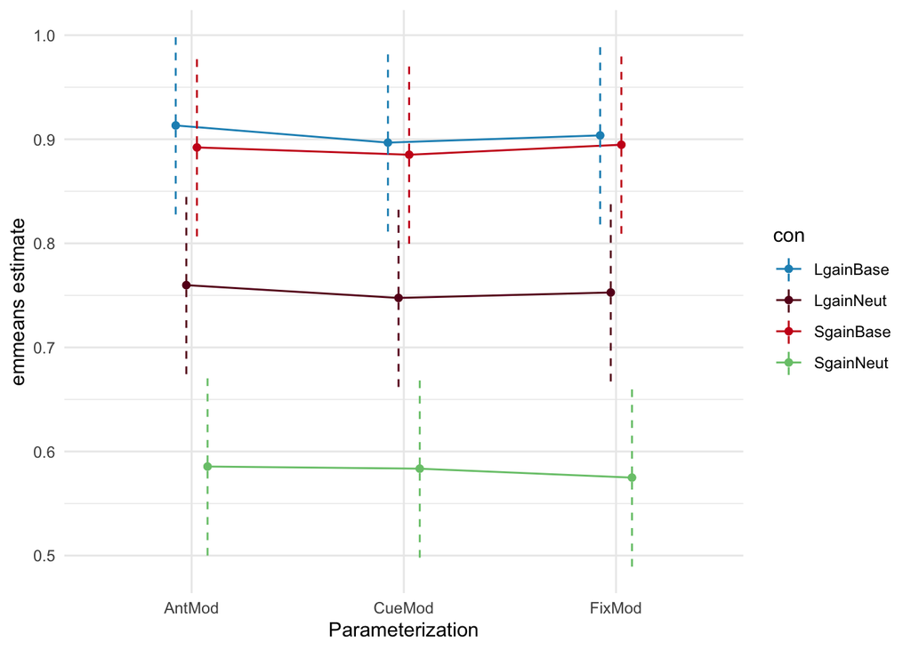

```r
emmip(model_interact, con ~ model, CIs = TRUE, style = "factor",
      dodge = .2, CIarg = list(linetype = "dashed"),
      xlab = "Parameterization", ylab = "emmeans estimate") +
  scale_color_manual(values = pal) + theme_minimal()
```